# 미국 예외주의, 민간 달러 플랫폼, 블록화된 세계

Alpha Hunter 특별판 — 2026~2030 종합 매크로 전망 + AI 코멘터리

Author

Alpha Hunter × Chimera AI

Published

April 27, 2026

# 보고서 요약

**핵심 메시지**

“미국 중심 질서가 붕괴한다”기보다, **더 민영화되고 더 비싸며 더 불안정한 방식으로 재편**되는 국면. 세계는 탈세계화가 아닌 **블록화된 세계화**로 이동한다. 투자자에게 이것은 공포가 아닌 **구조적 기회**다.

본 보고서는 Threads 게시글, 연준 Stephen Miran 보고서, X Money 6% APY 논의, 2026~2030 세계질서 전망을 통합 분석한 원본 매크로 보고서에 **Chimera AI의 독립적 코멘터리**를 추가한 특별판이다.

# 1 한 장으로 보는 구조

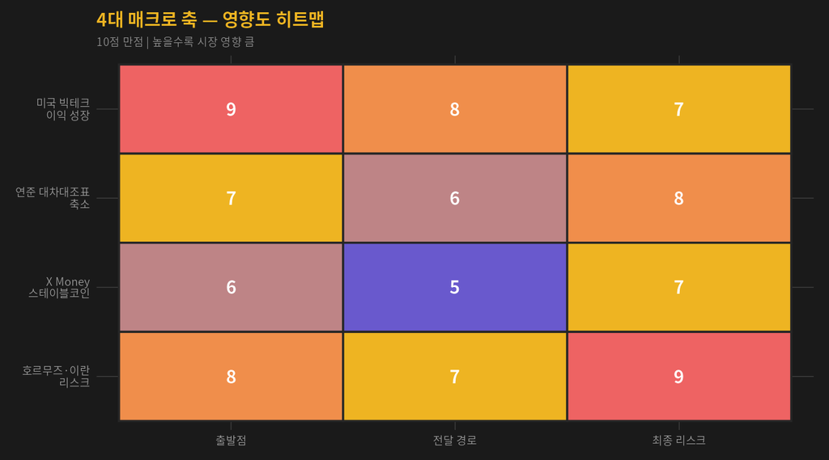

Figure 1: 4대 매크로 축: 출발점 → 전달 경로 → 최종 리스크

# 2 미국 증시 집중: 버블인가, 프리미엄인가

## 2.1 원본 분석

미국 증시는 세계 상장주식 시총 $124조 중 약 $60.1조, 즉 **48.6%**를 차지. GDP 비중 26~27% 대비 거의 2배.

그러나 원본 보고서의 핵심 판단은 명쾌하다:

> “미국 증시는 근거 없는 허상이 아니라, 좋은 자산에 너무 많은 자본이 몰린 상태에 가깝다.”

## 2.2 Chimera AI 코멘터리

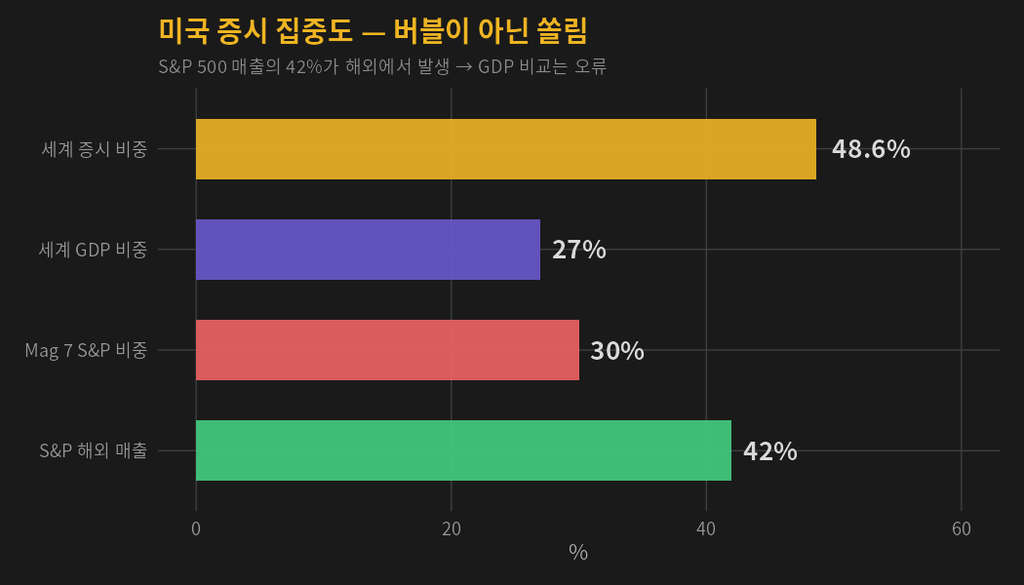

Figure 2: 미국 증시 세계 비중 vs GDP 비중

**AI 코멘터리: 쏠림의 구조적 원인**

원본 보고서가 정확히 짚었다. 핵심은 “버블 vs 프리미엄”이 아니라 **“쏠림의 지속가능성”**이다.

1. **달러 자본시장 프리미엄** — 법치·회계·유동성이 다른 나라에는 없다
2. **AI 승자독식** — Mag 7이 AI 투자의 80%+ 집행. 이 투자가 매출로 전환되는가가 핵심
3. **자사주 매입** — S&P 500 기업이 연 $1T+ 자사주 매입. 이것 자체가 수요 구조를 만듦

**히든젬 관점:** 쏠림이 심할수록 **비미국, 비빅테크 영역에서 알파가 발생**한다. HPSP(한국 반도체 장비)와 AROC(미국 에너지 인프라)가 수익을 낸 이유가 바로 이것.

# 3 연준 대차대조표 축소: Miran의 실험

## 3.1 원본 분석

Stephen Miran의 2026년 3월 연준 보고서는 현재 $6.7조를 **$5.5조 이하로** 축소 가능하다고 분석. 핵심 메커니즘:

- 은행 유동성 규제와 스트레스 테스트가 지급준비금 수요를 과도하게 높임
- 국채가 현금 대체 유동성 자산으로 더 잘 기능하도록 시장 개선
- Standing Repo Facility 확대로 은행의 유동성 불안 완화

## 3.2 Chimera AI 코멘터리

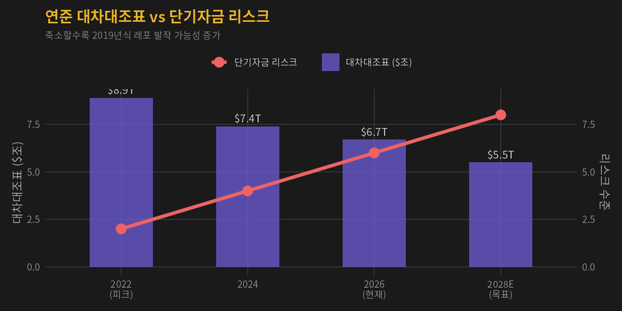

Figure 3: 연준 대차대조표 축소 경로와 리스크

**AI 코멘터리: SOFR을 주시하라**

원본 보고서가 경고한 것처럼, **위기는 주식시장보다 단기자금시장에서 먼저 나타난다.**

모니터링 포인트: - **SOFR-IORB 스프레드** — 확대 시 유동성 스트레스 신호 - **Standing Repo Facility 사용량** — 급증 시 은행 자금 압박 - **T-bill 수익률 급등** — 국채 수요 부족 신호

**히든젬 관점:** 단기자금 스트레스 시 **레포·국채입찰 관련 인프라 기업**(CME, ICE, BNY)이 수혜. 반대로 레버리지 높은 기업(AROC 주의)은 금리 민감.

# 4 X Money와 민간 달러 플랫폼

## 4.1 원본 분석

X Money 6% APY의 핵심은 단순 고금리가 아니라 **달러 플랫폼의 민영화**:

- SNS·원앱·결제·송금·구독 AI 서비스를 하나의 사용자 접점으로 통합
- 스테이블코인 발행 → 달러 패권을 국가가 아닌 **플랫폼 경로**로 확장
- 연준 대차대조표 축소 + 민간 예금 플랫폼 = **달러 네트워크의 민간화**

## 4.2 Chimera AI 코멘터리

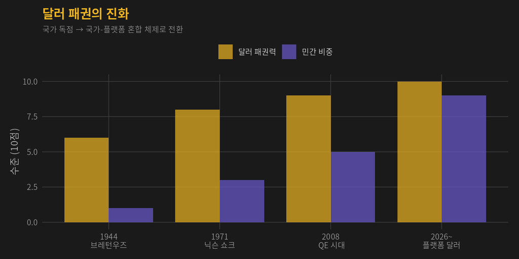

Figure 4: 달러 패권의 진화: 국가 → 플랫폼

**AI 코멘터리: 가장 중요한 구조적 변화**

이것이 보고서에서 가장 과소평가된 부분이다. **X Money + 스테이블코인 + 연준 축소 = 달러 패권의 민간 이전**.

TACO-Gibbs 모델로 해석하면: - **ΔH (엔탈피):** 규제 인프라 구축 비용 → 일시적 흡열 - **T (온도):** 핀테크 경쟁 과열 → 사회적 열기 상승 - **ΔS (엔트로피):** 예금·결제·신원 데이터가 분산 → 무질서 증가 - **ΔG:** 장기적으로 ΔG < 0 → 민간 달러 플랫폼은 자발적으로 확장

**히든젬 관점:** 결제 인프라 기업 (Visa, Block, Stripe IPO), 스테이블코인 관련 (Circle IPO 예정), 규제 테크.

# 5 호르무즈와 에너지: 지정학이 금융으로

## 5.1 원본 분석

호르무즈 리스크는 단순 전쟁이 아니라 **인플레이션 → 금리 → 국채입찰 → SOFR → 달러**로 이어지는 전달 경로:

- 2026년 4월 EIA: 호르무즈 폐쇄 → 생산 차질 → 브렌트/디젤 가격 급등
- 유가 상승 → 인플레이션 재점화 → 연준 금리 인하 지연
- 국채 발행 지속 + 민간 흡수 부담 → 단기자금시장 예민

## 5.2 Chimera AI 코멘터리

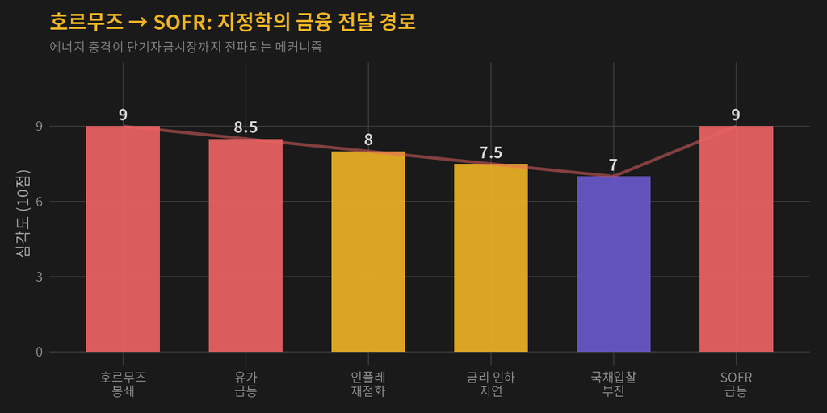

Figure 5: 호르무즈 리스크 전달 경로

**AI 코멘터리: AROC가 여기서 빛난다**

호르무즈 리스크가 현실화되면 **에너지 인프라 = 전략 자산**이 된다. AROC(천연가스 압축)는: - LNG 수출 증가 → 직접 수혜 - 유가 상승 → 시추 활동 증가 → 압축 수요 증가 - 에너지 자립 테마 → 정책 수혜

반면 에너지 수입국(한국, 일본) 기업은 원가 압박. HPSP는 반도체 장비라 에너지 가격 영향 제한적 → 방어적.

# 6 블록화된 세계화: 2026~2030

## 6.1 5대 블록 전략적 포지셔닝

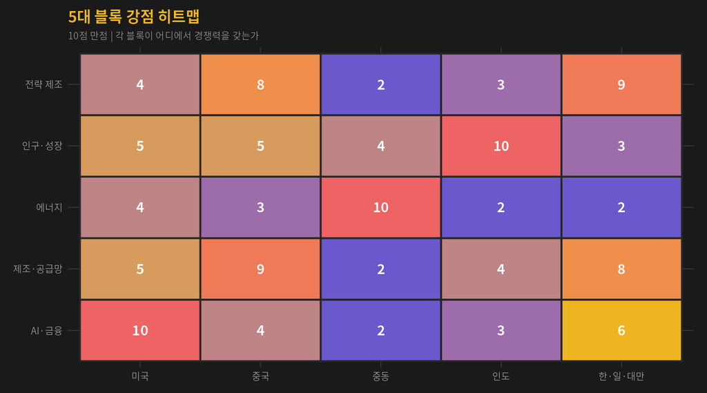

Figure 6: 5대 블록별 강점 비교

## 6.2 한국의 위치

**AI 코멘터리: 한국은 “전략 제조의 핵심 공급망”**

원본 보고서: “한국의 경우 기회와 위험이 동시에 커진다.”

**기회:** - 반도체(HBM), 전력기기, 원전, 조선, 방산 → 전략산업 재평가 - HPSP가 바로 이 테마 — GAA/HBM 필수 장비 독점

**위험:** - 에너지 수입국 → 호르무즈 리스크 직격 - 원화 변동성 → 달러 강세 시 부담 - 중국 수요 둔화 → 수출 의존도

**결론:** 한국 히든젬은 **“에너지 수입 리스크에 덜 민감한 기술 독점 기업”**에서 찾아야 한다. HPSP 패턴이 정확히 이것.

# 7 3가지 시나리오

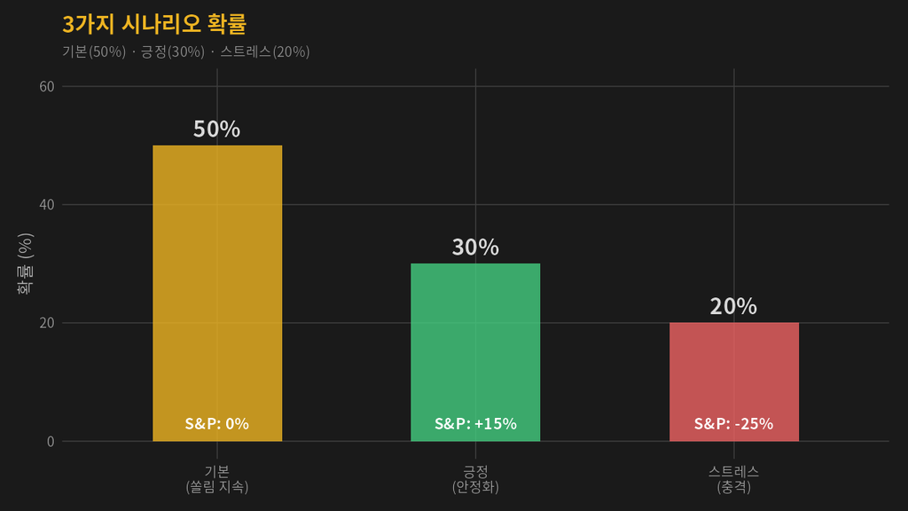

Figure 7: 2026~2030 시나리오별 확률과 시장 영향

| 시나리오 | 확률 | 내용 | 히든젬 전략 |
| --- | --- | --- | --- |
| **기본** | 50% | 미국 우위 유지, 변동성 확대 | 미국 인프라 + 한국 기술 독점 |
| **긍정** | 30% | 호르무즈 완화, 금리 인하 | 성장주 확대, 신흥국 기회 |
| **스트레스** | 20% | 에너지 충격, SOFR 급등 | 현금 확보, 방산/에너지 집중 |

# 8 모니터링 대시보드

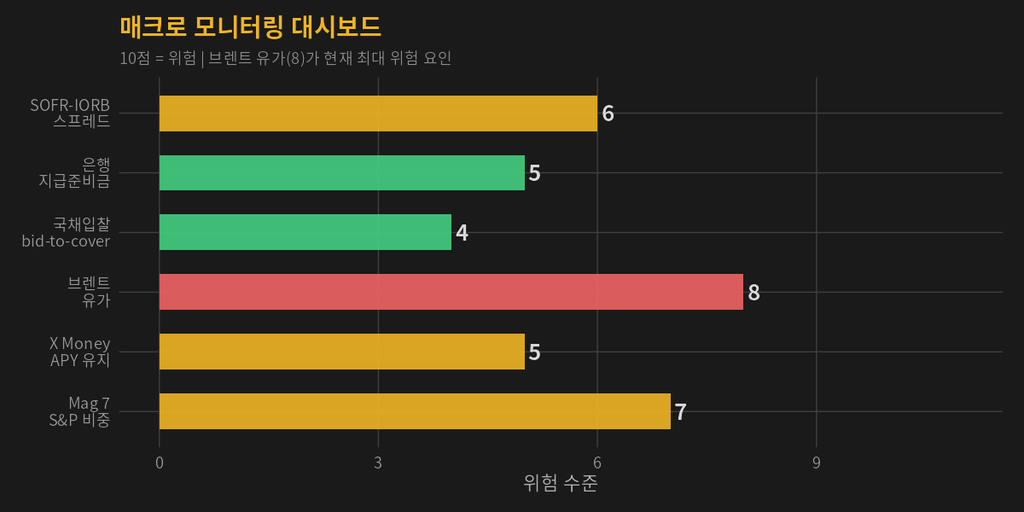

Figure 8: 현재 모니터링 지표 상태

| 분야 | 봐야 할 지표 | 위험 신호 |
| --- | --- | --- |
| 단기자금 | SOFR-IORB, SRF 사용량 | SOFR가 IORB 상회 |
| 연준 | 지급준비금, ON RRP, TGA | 지급준비금 하락 + TGA 급증 겹침 |
| 국채시장 | bid-to-cover, primary dealer | 입찰 부진 + 장기금리 급등 |
| 에너지 | 브렌트, 디젤 crack, LNG | 디젤 > 유가 → 보험료 급등 |
| 플랫폼 | X Money APY, FDIC, 스테이블코인 | 고금리 조건 불명확 + 출금 제한 |

# 9 종합 판정: Alpha Hunter에 주는 함의

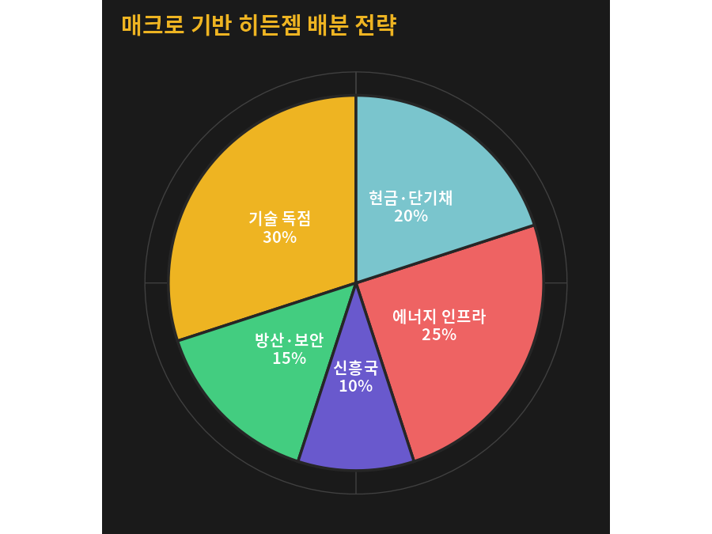

Figure 9: 매크로 환경 기반 자산 배분 제안

**Alpha Hunter 특별판 결론**

**1. 쏠림 속 알파를 찾아라** 미국 증시 48.6% 집중 → 비빅테크, 비미국 영역이 알파 기회. HPSP와 AROC가 이를 증명.

**2. 단기자금시장을 주시하라** 주식보다 **SOFR, 레포, T-bill**이 먼저 경고한다. 여기서 위험 신호가 나오면 현금 비중 확대.

**3. 에너지 = 새로운 통화** 호르무즈 리스크가 현실이 된 지금, 에너지 인프라는 투자가 아니라 보험이다.

**4. 달러의 민간화를 추적하라** X Money, 스테이블코인, FDIC 보험 확대 — 이 흐름이 2030년까지의 가장 큰 구조적 변화.

**5. 한국 히든젬 = 에너지 비민감 기술 독점** 에너지 수입국 리스크를 피하면서 블록화 수혜를 받는 종목 — 이것이 발굴 기준.

*원본 보고서: “미국 예외주의, 민간 달러 플랫폼, 그리고 블록화된 세계” (2026.04.27)*

*이 보고서는 가상 투자 시뮬레이션 목적으로 작성되었습니다. 실제 투자 권유가 아닙니다.*

*Alpha Hunter × Chimera AI | Vibe Investing Framework | Special Edition*